# Model Diagnostics

# Summaries for model run: 106

### Quick look

- Dataset: ../data/derived/pk.csv
- Number of subjects: 160
- Number of observations: 3142
- Number of records: 4292
- Objective function value (final est. method): 30904.4
- Condition number: 48.5
- Figures saved to: results/figure/diagnostics/106

Model description (from yaml file) is included below:

*Two-compartment model with first-order absorption and linear elimination. Effects of eGFR, age, and ALB on CL/F.*

### Output summaries from bbr

── NONMEM Model Status ───────────────────────────

• Finished Running

── Absolute Model Path ───────────────────────────

• /data/home/sethg/client-projects/AZN07/poppk-template/models/pk/106

── YAML & Model Files ───────────────────────────

• /data/home/sethg/client-projects/AZN07/poppk-template/models/pk/106.yaml

• /data/home/sethg/client-projects/AZN07/poppk-template/models/pk/106.ctl

── Attached Simulation ───────────────────────────

• Status: Finished Running

• Number of Simulations: 300

── Description ───────────────────────────────

• Two-compartment model with first-order absorption and linear elimination. Effects of eGFR, age, and ALB on CL/F.

── Notes ──────────────────────────────────

• 1: Client was interested in adding Albumin to CL Dataset: ../../../data/derived/pk.csv

Records: 4292 Observations: 3142 Subjects: 160

Objective Function Value (final est. method): 30904.409

Estimation Method(s):

– First Order Conditional Estimation with Interaction

Simulation: Yes (N = 300)

No Heuristic Problems Detected

| parameter_names | estimate | stderr | shrinkage |
| --- | --- | --- | --- |
| THETA1 | 0.443 | 0.0643 |  |
| THETA2 | 4.12 | 0.0275 |  |
| THETA3 | 1.17 | 0.0280 |  |
| THETA4 | 4.21 | 0.0190 |  |
| THETA5 | 1.28 | 0.0348 |  |
| THETA6 | 0.485 | 0.0395 |  |
| THETA7 | -0.0378 | 0.0635 |  |
| THETA8 | 0.419 | 0.0863 |  |
| OMEGA(1,1) | 0.219 | 0.0526 | 14.4 |
| OMEGA(2,2) | 0.0824 | 0.00981 | 5.51 |
| OMEGA(3,3) | 0.114 | 0.0128 | 1.25 |
| SIGMA(1,1) | 0.0399 | 0.00123 | 5.02 |

# General diagnostic plots

## DV vs PRED and IPRED

DV vs PRED and IPRED linear scale

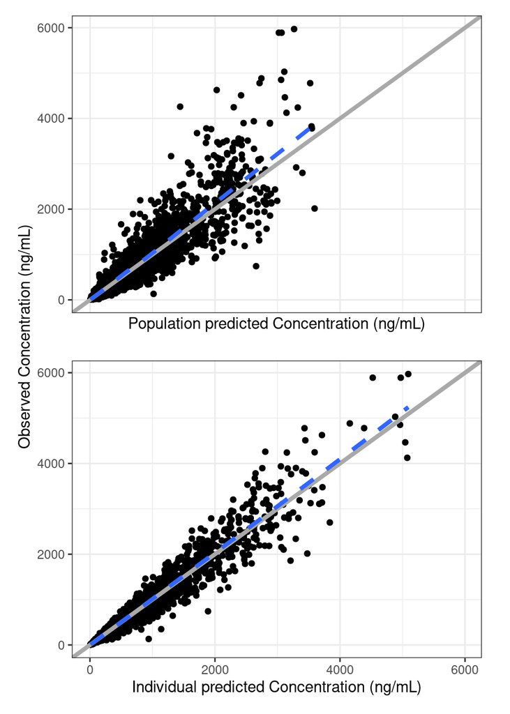

DV vs PRED and IPRED log scale

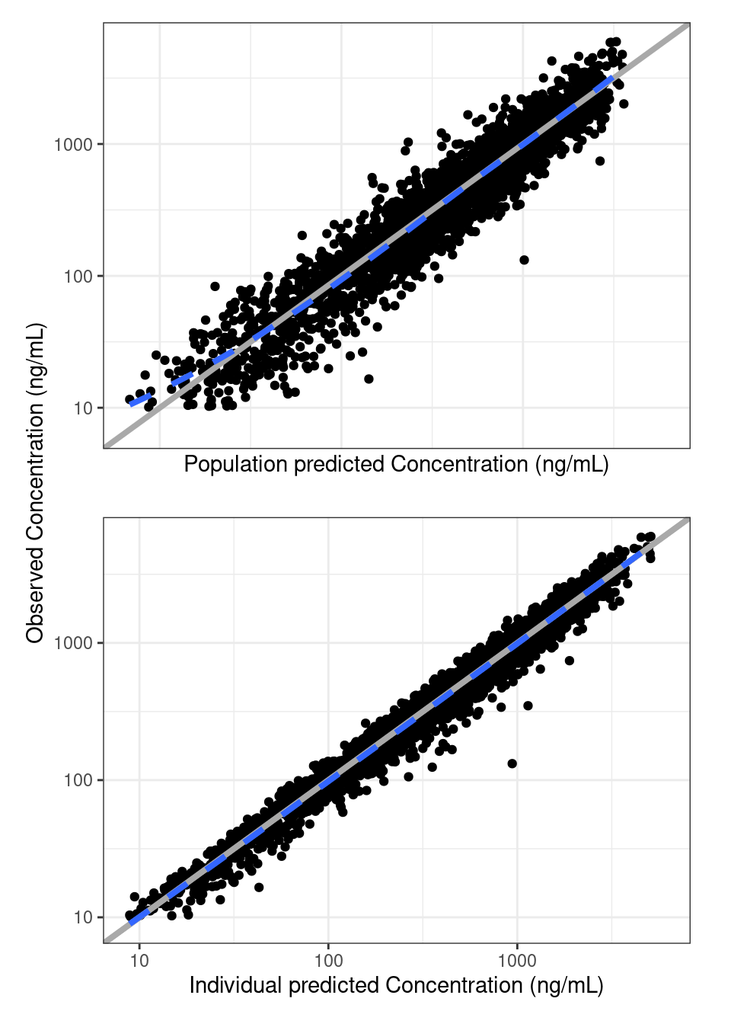

## CWRES plots

CWRES vs PRED, time and time after dose.

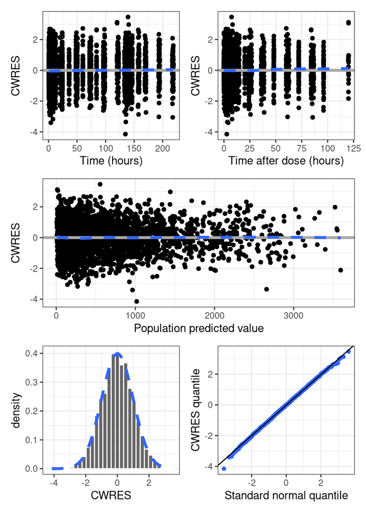

# EBEs-based diagnostics

## ETA pairs plot

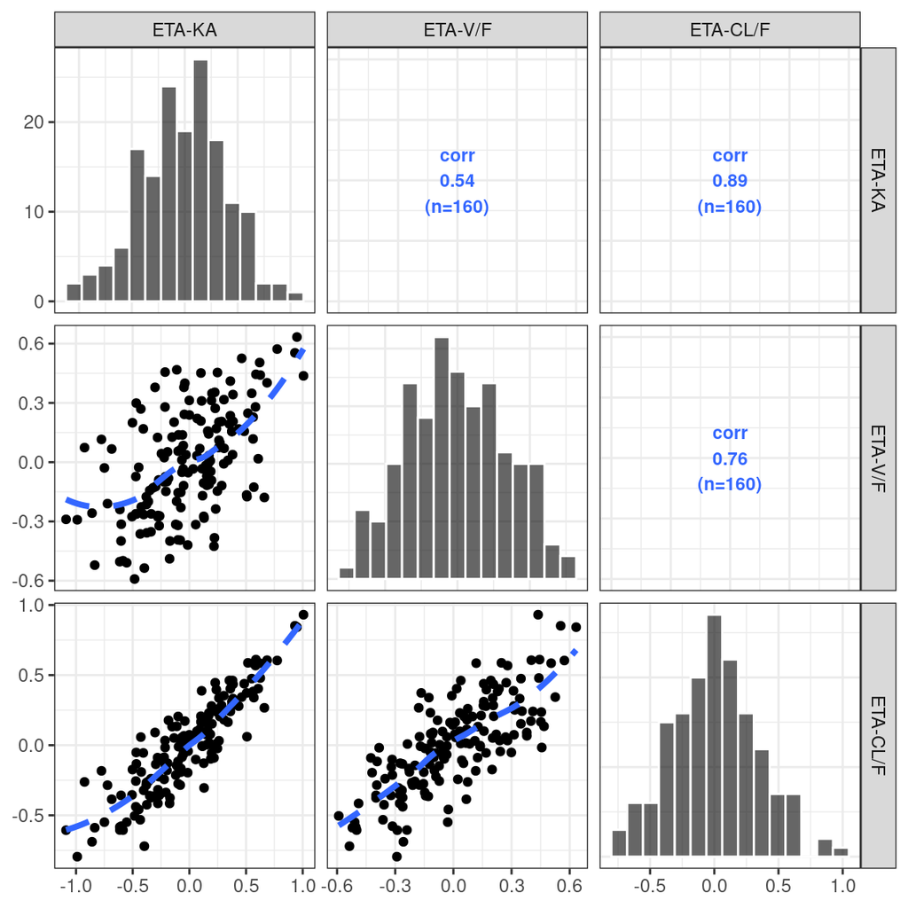

## ETA vs continous covariates

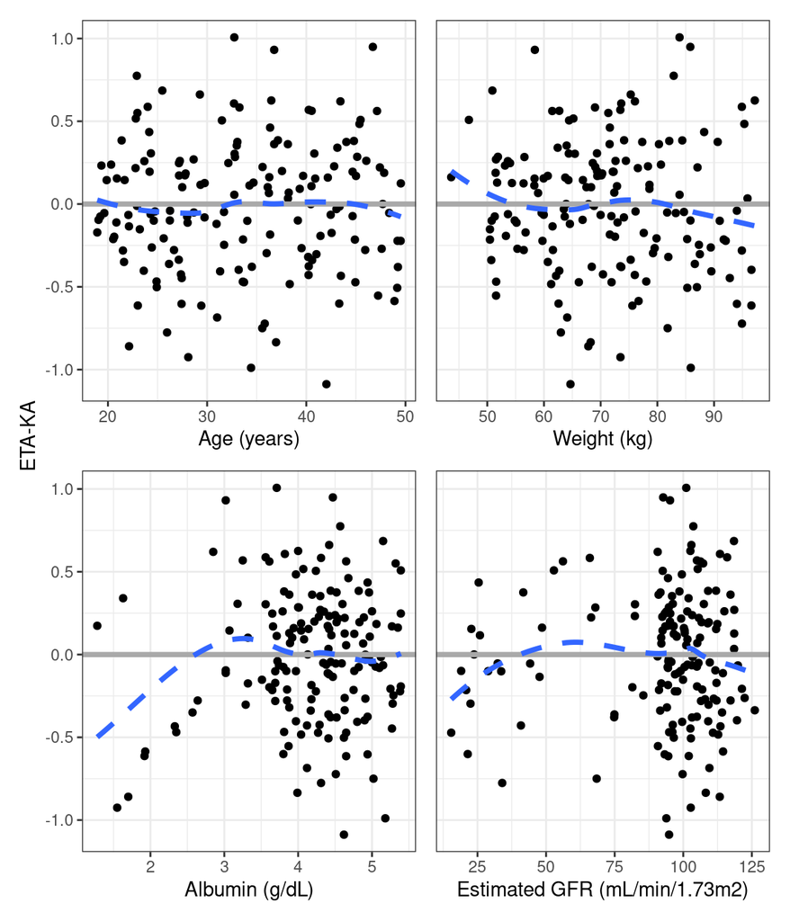

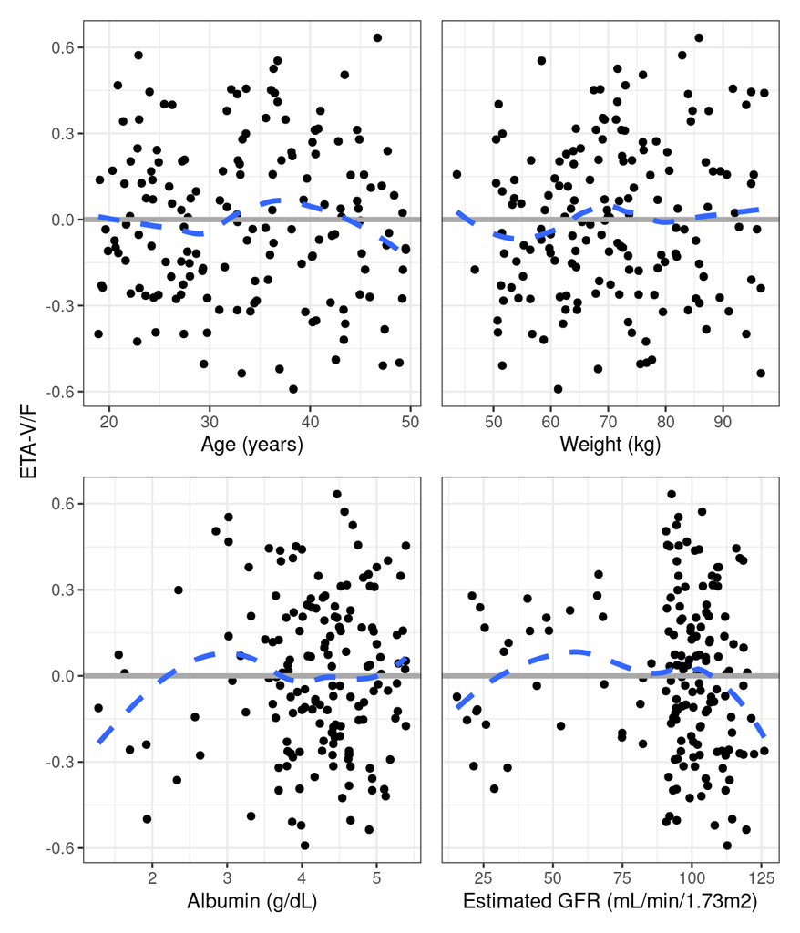

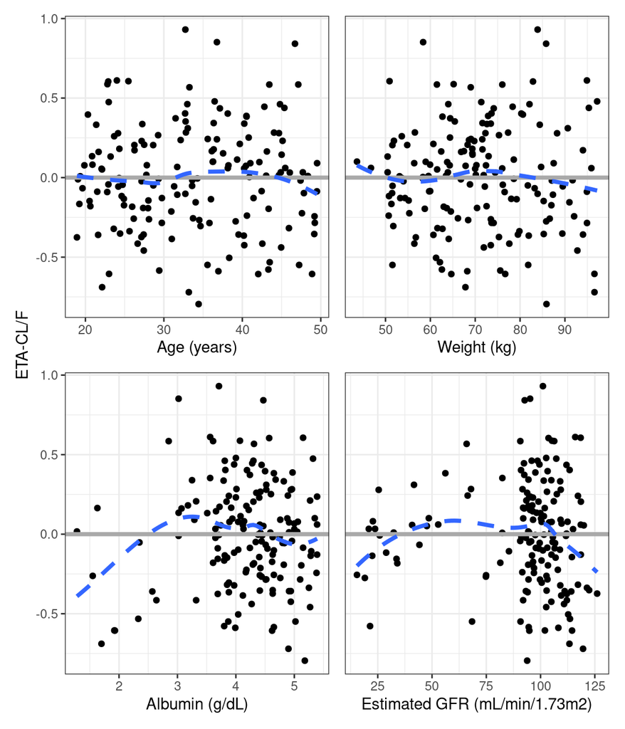

## ETA vs categorical covariates

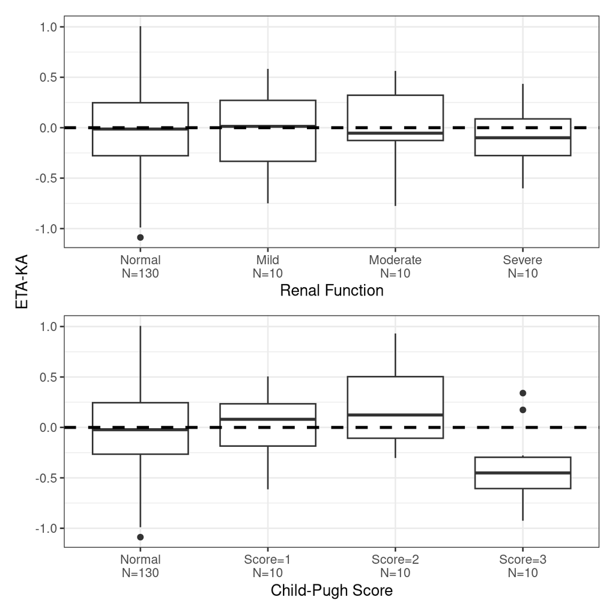

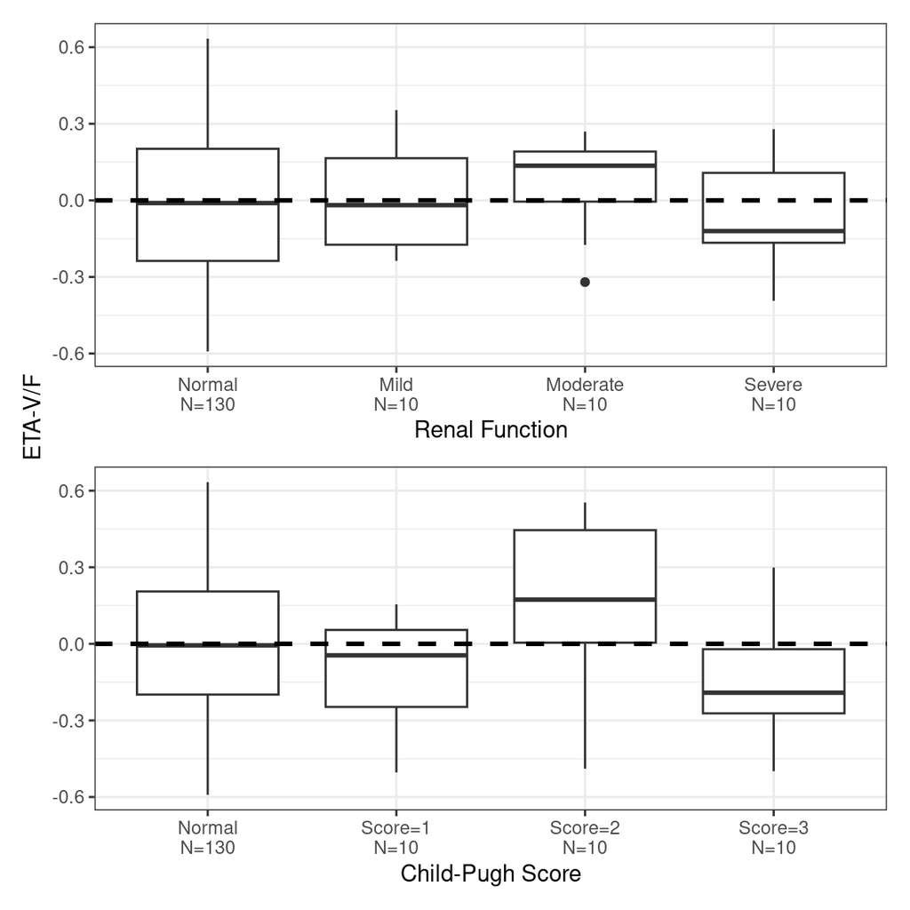

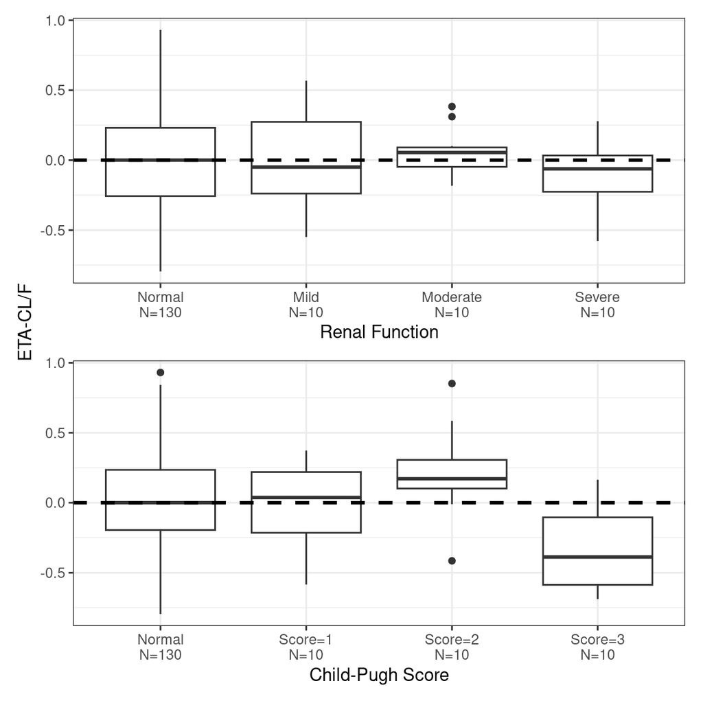

# Session details

```
## [1] "Fri Mar 28 15:21:15 2025"
```

```
## [1] "3.3.0"
```